# SA1 DSC1105

Lindsay Faith Bazar

March 19, 2025

## Unit 1: Univariate Data Analysis

#### 1. Load the dataset and summarize its structure.

```r
suppressPackageStartupMessages(suppressWarnings({
library(tidyverse)
library(ggplot2)
library(kableExtra)
library(gridExtra)
library(grid)
library(e1071)
library(broom)
}))

data <- read.csv("EDA_Ecommerce_Assessment.csv")
summary(data)
```

```
##   Customer_ID        Gender               Age        Browsing_Time
##  Min.   :   1.0   Length:3000        Min.   :18.00   Min.   :  1.00
##  1st Qu.: 750.8   Class :character   1st Qu.:31.00   1st Qu.: 29.98
##  Median :1500.5   Mode  :character   Median :44.00   Median : 59.16
##  Mean   :1500.5                      Mean   :43.61   Mean   : 59.87
##  3rd Qu.:2250.2                      3rd Qu.:57.00   3rd Qu.: 89.33
##  Max.   :3000.0                      Max.   :69.00   Max.   :119.95
##  Purchase_Amount  Number_of_Items Discount_Applied Total_Transactions
##  Min.   :  5.03   Min.   :1.00    Min.   : 0.00    Min.   : 1.00
##  1st Qu.:128.69   1st Qu.:3.00    1st Qu.:12.00    1st Qu.:12.00
##  Median :245.09   Median :5.00    Median :24.00    Median :24.00
##  Mean   :247.96   Mean   :4.99    Mean   :24.34    Mean   :24.68
##  3rd Qu.:367.20   3rd Qu.:7.00    3rd Qu.:37.00    3rd Qu.:37.00
##  Max.   :499.61   Max.   :9.00    Max.   :49.00    Max.   :49.00
##    Category         Satisfaction_Score
##  Length:3000        Min.   :1.000
##  Class :character   1st Qu.:2.000
##  Mode  :character   Median :3.000
##                     Mean   :3.066
##                     3rd Qu.:4.000
##                     Max.   :5.000
```

The dataset contains 3,000 customer records. It has 10 variables, including customer demographics, purchase details, and satisfaction scores.

#### 2. Create histograms and boxplots to visualize the distribution of Purchase_Amount, Number_of_Items, and Satisfaction_Score.

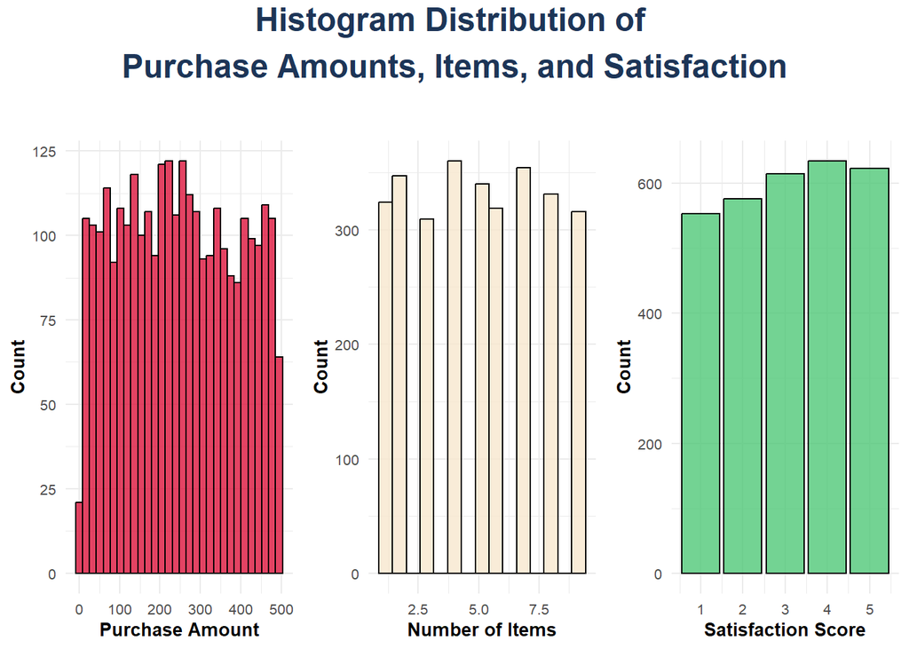

```r
theme_custom <- theme_minimal() + theme(
  plot.title = element_text(size = 12, face = "bold"),
  axis.title = element_text(size = 10, face = "bold"),
  axis.text = element_text(size = 8)
)


h1 <- ggplot(data, aes(Purchase_Amount)) +
  geom_histogram(bins = 30, fill =  "#DC143C", color = "black", alpha = 0.8) +
  labs(x = "Purchase Amount", y = "Count") +
  theme_custom

h2 <- ggplot(data, aes(Number_of_Items)) +
  geom_histogram(bins = 15, fill = "#F7E7CE", color = "black", alpha = 0.8) +
  labs(x = "Number of Items", y = "Count") +
  theme_custom

h3 <- ggplot(data, aes(Satisfaction_Score)) +
  geom_bar(fill = '#50C878', color = "black", alpha = 0.8) +
  labs(x = "Satisfaction Score", y = "Count") +
  theme_custom


grid.arrange(h1, h2, h3, nrow = 1, top = textGrob("Histogram Distribution of \nPurchase Amounts, Items, and Satisfaction\n", gp = gpar(fontsize = 18, fontface = "bold", col = "#1D3557"))
)
```

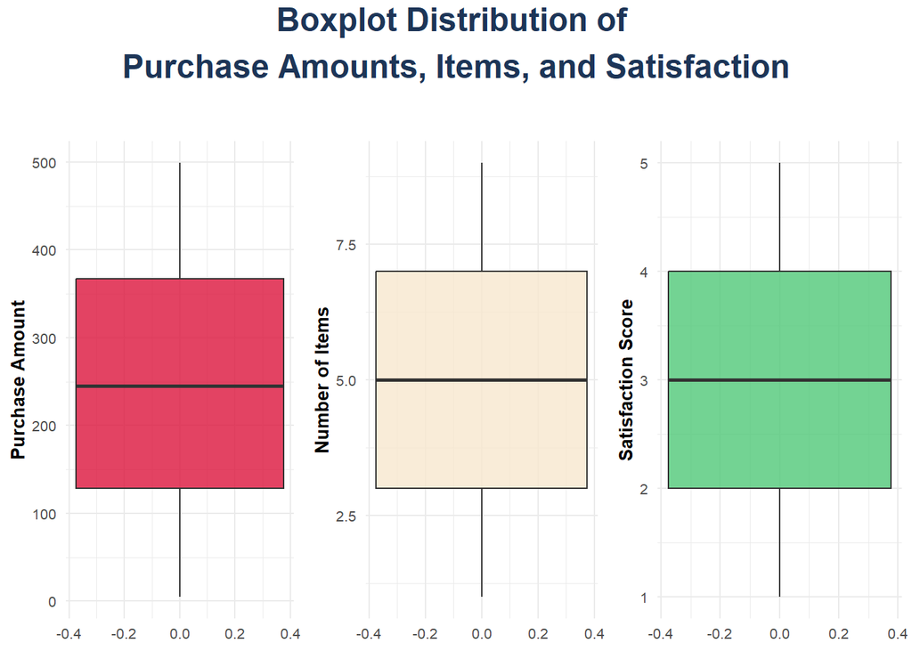

```r
b1 <- ggplot(data, aes(y = Purchase_Amount)) +
  geom_boxplot(fill = "#DC143C", alpha = 0.8) +
  labs(y = "Purchase Amount") +
  theme_custom

b2 <- ggplot(data, aes(y = Number_of_Items)) +
  geom_boxplot(fill = "#F7E7CE", alpha = 0.8) +
  labs(y = "Number of Items") +
  theme_custom

b3 <- ggplot(data, aes(y = Satisfaction_Score)) +
  geom_boxplot(fill = "#50C878", alpha = 0.8) +
  labs(y = "Satisfaction Score") +
  theme_custom


grid.arrange(b1, b2, b3, nrow = 1, top = textGrob("Boxplot Distribution of \nPurchase Amounts, Items, and Satisfaction\n", gp = gpar(fontsize = 18, fontface = "bold", col = "#1D3557"))
)
```

#### 3. Compute measures of central tendency (mean, median, mode) and spread (variance, standard deviation, IQR) for Purchase_Amount.

```r
summary_purchase <- data %>%
  summarise(
    Statistic = c("Mean", "Median", "Mode", "Standard Deviation", "Variance", "Interquartile Range"),
    Value = c(
      mean(Purchase_Amount, na.rm = TRUE),
      median(Purchase_Amount, na.rm = TRUE),
      as.numeric(names(sort(table(Purchase_Amount), decreasing = TRUE)[1])),
      sd(Purchase_Amount, na.rm = TRUE),
      var(Purchase_Amount, na.rm = TRUE),
      IQR(Purchase_Amount, na.rm = TRUE)
    )
  )

kable(summary_purchase, caption = "Amount Purchase Statistics", col.names = c("Statistic", "Value")) %>%
  kable_styling(full_width = FALSE, bootstrap_options = c("striped", "hover"))
```

Amount Purchase Statistics

| Statistic | Value |
| --- | --- |
| Mean | 247.9625 |
| Median | 245.0900 |
| Mode | 29.3300 |
| Standard Deviation | 140.8758 |
| Variance | 19845.9862 |
| Interquartile Range | 238.5050 |

#### 4. Compare the distribution of Browsing_Time and Purchase_Amount across different Gender groups using density plots.

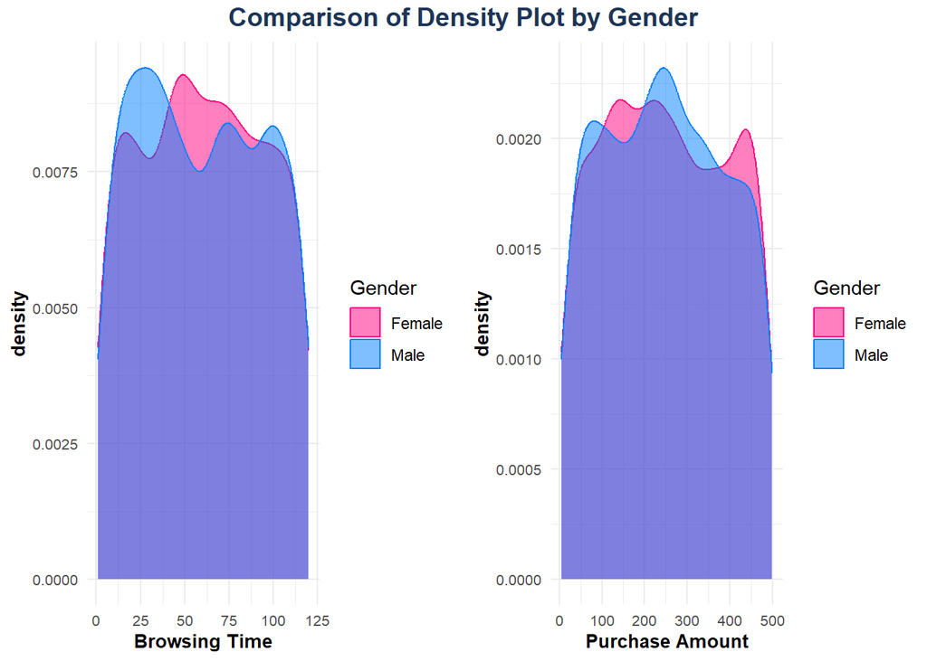

```r
bt <- ggplot(data, aes(x = Browsing_Time, color = Gender, fill = Gender)) +
  geom_density(alpha = 0.5) +
  scale_color_manual(values = c("Female" = "#FF007F", "Male" = "#007FFF")) +
  scale_fill_manual(values = c("Female" = "#FF007F", "Male" = "#007FFF")) +
  labs(x = "Browsing Time")  +
  theme_custom

pa <- ggplot(data, aes(x = Purchase_Amount, color = Gender, fill = Gender)) +
  geom_density(alpha = 0.5) +
  scale_color_manual(values = c("Female" = "#FF007F", "Male" = "#007FFF")) +
  scale_fill_manual(values = c("Female" = "#FF007F", "Male" = "#007FFF")) +
  labs(x = "Purchase Amount") +
  theme_custom

grid.arrange(bt, pa, ncol = 2, top = textGrob("Comparison of Density Plot by Gender", gp = gpar(fontsize = 14, fontface = "bold", col = "#1D3557")))
```

#### 5. Apply a logarithmic or square root transformation on Browsing_Time and evaluate changes in skewness.

```r
data <- data %>% mutate(
  Browsing_Time_Log = log1p(Browsing_Time),
  Browsing_Time_Sqrt = sqrt(Browsing_Time)
)

skewness_values <- tibble(
  Measure = c("Original Skewness", "Log Transformed Skewness", "Sqrt Transformed Skewness"),
  Value = c(
    skewness(data$Browsing_Time, na.rm = TRUE),
    skewness(data$Browsing_Time_Log, na.rm = TRUE),
    skewness(data$Browsing_Time_Sqrt, na.rm = TRUE)
  )
)

kable(skewness_values, caption = "Browsing Time Skewness Transformation" , col.names = c("Measure", "Value"), align = "c") %>%
  kable_styling(full_width = FALSE, bootstrap_options = c("striped", "hover"))
```

Browsing Time Skewness Transformation

| Measure | Value |
| --- | --- |
| Original Skewness | 0.0386156 |
| Log Transformed Skewness | -1.2183734 |
| Sqrt Transformed Skewness | -0.4768351 |

#### 6. Fit a simple linear regression model predicting Purchase_Amount based on Browsing_Time. Interpret the results.

```r
model <- lm(Purchase_Amount ~ Browsing_Time, data = data)
sum_model <- summary(model)

kable(tidy(sum_model), caption = " Linear Regression Model of Amount Purchase based on Browsing Time", col.names = c("Term", "Estimate", "Std. Error", "t value", "Pr(>|t|)"), align = "c") %>%
  kable_styling(full_width = FALSE, bootstrap_options = c("striped", "hover"))
```

Linear Regression Model of Amount Purchase based on Browsing Time

| Term | Estimate | Std. Error | t value | Pr(>&#124;t&#124;) |
| --- | --- | --- | --- | --- |
| (Intercept) | 252.6559564 | 5.1752405 | 48.82014 | 0.0000000 |
| Browsing_Time | -0.0783949 | 0.0750118 | -1.04510 | 0.2960611 |

The intercept is the predicted purchase amount when Browsing Time = 0. If someone doesn’t spend any time browsing, the expected purchase amount is ₱252.66.

In addition, for every additional unit of browsing time, the purchase amount is expected to decrease slightly by ₱0.078. However, this change is not meaningful or strong enough to confidently say browsing time affects spending.

Lastly, since the p-value is greater than 0.05, the effect of browsing time is not statistically significant, which means that browsing time doesn’t directly impact how much people spend.

#### 7. Use ggplot2 (or equivalent) to create scatter plots and regression lines.

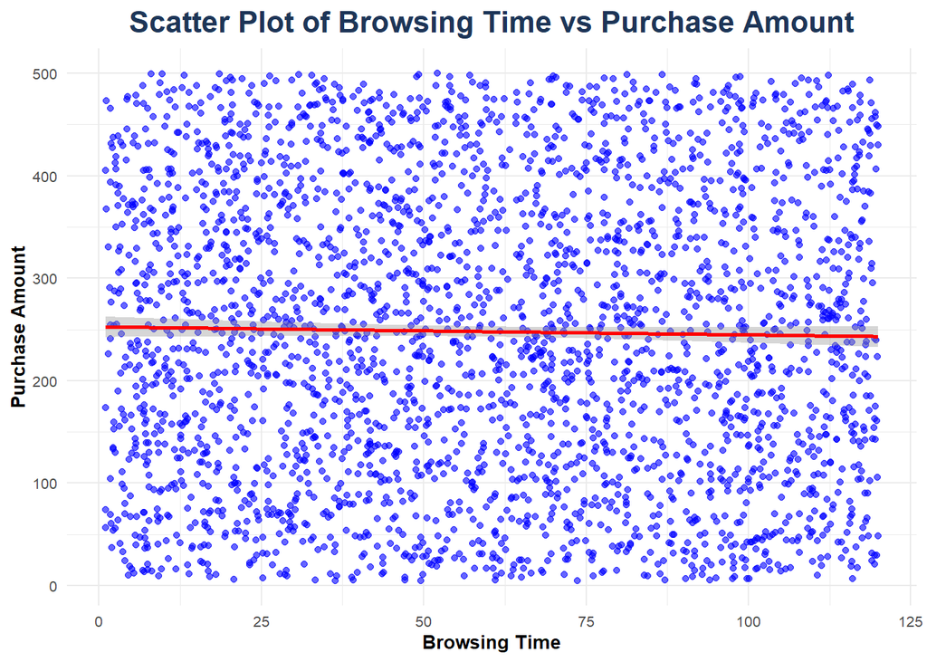

```r
ggplot(data, aes(x = Browsing_Time, y = Purchase_Amount)) +
  geom_point(alpha = 0.6, color = "blue") +
  geom_smooth(method = "lm", se = TRUE, color = "red") +
  labs(title = "Scatter Plot of Browsing Time vs Purchase Amount", x = "Browsing Time", y = "Purchase Amount") +
  theme_custom +
  theme(plot.title = element_text(hjust = 0.5, color = "#1D3557", size = 16, face = "bold"))
```

The red trend line is almost flat, which means that there’s little to no relationship between browsing time and purchase amount. Thus, spending more time browsing does not significantly impact how much a customer spends.

## Unit 2: Bivariate Data Analysis

#### 8. Create scatter plots to explore the relationship between Purchase_Amount and Number_of_Items.

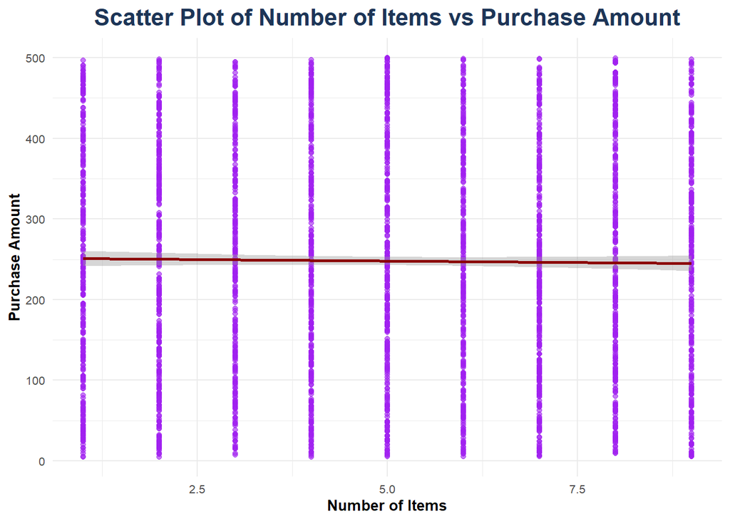

```r
ggplot(data, aes(x = Number_of_Items, y = Purchase_Amount)) +
  geom_point(alpha = 0.6, color = "purple") +
  geom_smooth(method = "lm", se = TRUE, color = "darkred") +
  labs(title = "Scatter Plot of Number of Items vs Purchase Amount", x = "Number of Items", y = "Purchase Amount") +
  theme_custom +
  theme(plot.title = element_text(hjust = 0.5, color = "#1D3557", size = 16, face = "bold"))
```

The trend line is also mostly flat, which means there’s little to no correlation between the number of items and the purchase amount.Thus, buying more items does not significantly increase or decrease the purchase amount.

#### 9. Fit a polynomial regression model for Purchase_Amount and Browsing_Time and compare it with a simple linear model.

```r
poly_model <- lm(Purchase_Amount ~ poly(Browsing_Time, 2), data = data)
poly_summary <- tidy(poly_model)

kable(poly_summary, caption = "Polynomial Regression Model for Amount Purchase and Browsing", align = "c") %>%
  kable_styling(full_width = FALSE, bootstrap_options = c("striped", "hover"))
```

Polynomial Regression Model for Amount Purchase and Browsing

| term | estimate | std.error | statistic | p.value |
| --- | --- | --- | --- | --- |
| (Intercept) | 247.96254 | 2.572317 | 96.3965604 | 0.0000000 |
| poly(Browsing_Time, 2)1 | -147.22700 | 140.891621 | -1.0449663 | 0.2961228 |
| poly(Browsing_Time, 2)2 | -68.12915 | 140.891621 | -0.4835571 | 0.6287355 |

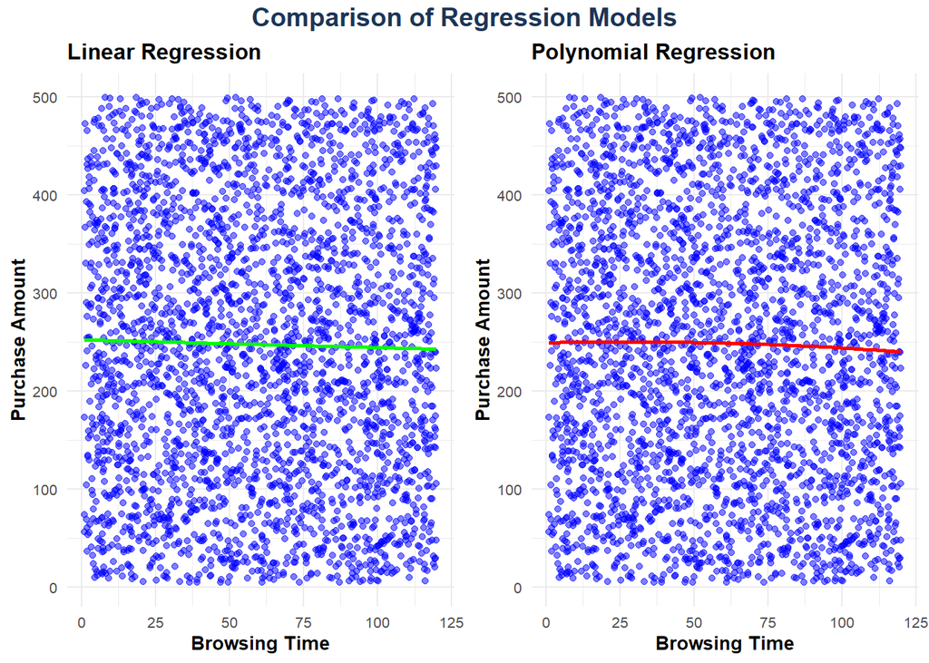

```r
lin <- ggplot(data, aes(x = Browsing_Time, y = Purchase_Amount)) +
  geom_point(alpha = 0.5, color = "blue") +
  geom_smooth(method = "lm", se = FALSE, color = "green") +
  labs(title = "Linear Regression", x = "Browsing Time", y = "Purchase Amount") +
  theme_custom


pol <- ggplot(data, aes(x = Browsing_Time, y = Purchase_Amount)) +
  geom_point(alpha = 0.5, color = "blue") +
  geom_smooth(method = "lm", se = FALSE, color = "red", formula = y ~ poly(x, 2)) +
  labs(title = "Polynomial Regression", x = "Browsing Time", y = "Purchase Amount") +
  theme_custom

grid.arrange(lin, pol, ncol = 2, top = textGrob("Comparison of Regression Models", gp = gpar(fontsize = 14, fontface = "bold", col = "#1D3557")))
```

Both models perform similarly with no clear advantage for polynomial regression in this case. Both regression models suggest that Browsing Time has little to no effect on Purchase Amount.

Since neither model identifies a clear trend, this suggests that browsing time alone may not be a strong predictor of purchase behavior.

#### 10. Apply LOESS (Locally Estimated Scatterplot Smoothing) to Purchase_Amount vs. Browsing_Time and visualize the results.

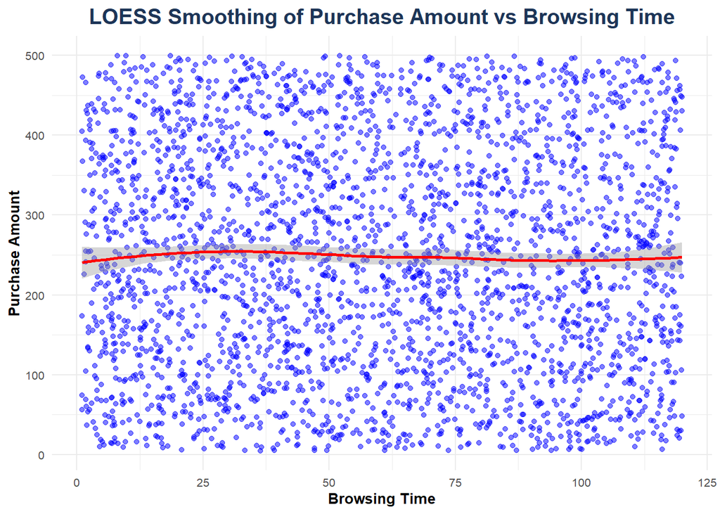

```r
ggplot(data, aes(x = Browsing_Time, y = Purchase_Amount)) +
  geom_point(alpha = 0.5, color = "blue") +
  geom_smooth(method = "loess", se = TRUE, color = "red") +
  labs(title = "LOESS Smoothing of Purchase Amount vs Browsing Time", x = "Browsing Time", y = "Purchase Amount") +
  theme_custom +
  theme(plot.title = element_text(hjust = 0.5, color = "#1D3557", size = 15, face = "bold"))
```

Although there is some fluctuations here and there, the red curve is mostly flat, which means that Browsing Time has little to no impact on Purchase Amount.

#### 11. Compare robust regression methods (Huber or Tukey regression) with ordinary least squares (OLS).

```r
library(MASS)

ols_model <- lm(Purchase_Amount ~ Browsing_Time, data = data)
huber_model <- rlm(Purchase_Amount ~ Browsing_Time, data = data, psi = psi.huber)
tukey_model <- rlm(Purchase_Amount ~ Browsing_Time, data = data, psi = psi.bisquare)

ols_summary <- tidy(model) %>% mutate(Model = "OLS")
huber_summary <- tidy(huber_model) %>% mutate(Model = "Huber")
tukey_summary <- tidy(tukey_model) %>% mutate(Model = "Tukey")

robust_comparison <- bind_rows(ols_summary, huber_summary, tukey_summary)

kable(
  robust_comparison,
  caption = "Comparison of OLS, Huber, and Tukey Robust Regression",
  col.names = c("Term", "Estimate", "Std. Error", "t value", "Pr(>|t|)", "Model"),
  align = "c"
) %>%
  kable_styling(full_width = FALSE, bootstrap_options = c("striped", "hover"))
```

Comparison of OLS, Huber, and Tukey Robust Regression

| Term | Estimate | Std. Error | t value | Pr(>&#124;t&#124;) | Model |
| --- | --- | --- | --- | --- | --- |
| (Intercept) | 252.6559564 | 5.1752405 | 48.820138 | 0.0000000 | OLS |
| Browsing_Time | -0.0783949 | 0.0750118 | -1.045100 | 0.2960611 | OLS |
| (Intercept) | 252.6461856 | 5.3362996 | 47.344828 | NA | Huber |
| Browsing_Time | -0.0802674 | 0.0773463 | -1.037767 | NA | Huber |
| (Intercept) | 252.8187489 | 5.5699388 | 45.389861 | NA | Tukey |
| Browsing_Time | -0.0883404 | 0.0807327 | -1.094232 | NA | Tukey |

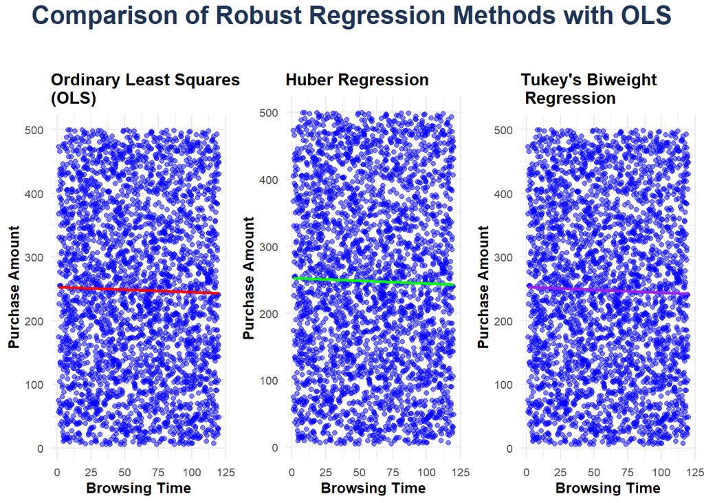

```r
pred_data <- data.frame(Browsing_Time = seq(min(data$Browsing_Time), max(data$Browsing_Time), length.out = 100))

pred_data$ols <- predict(ols_model, newdata = pred_data)
pred_data$huber <- predict(huber_model, newdata = pred_data)
pred_data$tukey <- predict(tukey_model, newdata = pred_data)

ols <- ggplot(data, aes(x = Browsing_Time, y = Purchase_Amount)) +
  geom_point(alpha = 0.5, color = "blue") +
  geom_line(data = pred_data, aes(x = Browsing_Time, y = ols), color = "red", size = 1) +
  labs(title = "Ordinary Least Squares \n(OLS)", x = "Browsing Time", y = "Purchase Amount") +
  theme_custom

hub <- ggplot(data, aes(x = Browsing_Time, y = Purchase_Amount)) +
  geom_point(alpha = 0.5, color = "blue") +
  geom_line(data = pred_data, aes(x = Browsing_Time, y = huber), color = "green", size = 1) +
  labs(title = "Huber Regression", x = "Browsing Time", y = "Purchase Amount") +
  theme_custom

tuk <- ggplot(data, aes(x = Browsing_Time, y = Purchase_Amount)) +
  geom_point(alpha = 0.5, color = "blue") +
  geom_line(data = pred_data, aes(x = Browsing_Time, y = tukey), color = "purple", size = 1) +
  labs(title = "Tukey's Biweight\n Regression", x = "Browsing Time", y = "Purchase Amount") +
  theme_custom

grid.arrange(ols, hub, tuk, ncol = 3, top = textGrob("Comparison of Robust Regression Methods with OLS\n", gp = gpar(fontsize = 18, fontface = "bold", col = "#1D3557")))
```

## Unit 3: Trivariate/Hypervariate Data Analysis

#### 12. Explore interaction effects between Browsing_Time and Category on Purchase_Amount using interaction plots.

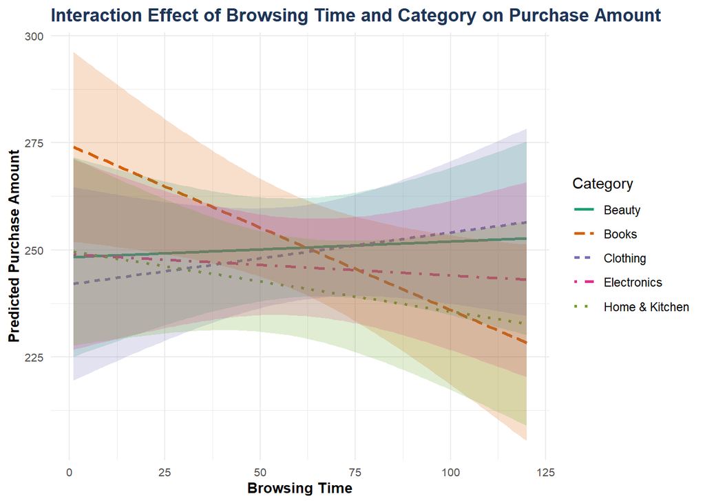

```r
library(interactions)

interaction_model <- lm(Purchase_Amount ~ Browsing_Time * Category, data = data)

interact_plot(interaction_model, pred = Browsing_Time, modx = Category,
              interval = TRUE, int.width = 0.95, colors = "Dark2") +
  labs(title = "Interaction Effect of Browsing Time and Category on Purchase Amount",
       x = "Browsing Time", y = "Predicted Purchase Amount") +
  theme_custom +
  theme(plot.title = element_text(color = "#1D3557", size = 13, face = "bold"))
```

Books show a noticeable decrease in purchase amount with longer browsing times. While clothing shows a slight increase in purchase amount with longer browsing times. Other categories like Beauty and Electronics show minimal impact from browsing time.

#### 13. Create coplots of Purchase_Amount against Browsing_Time for different levels of Category.

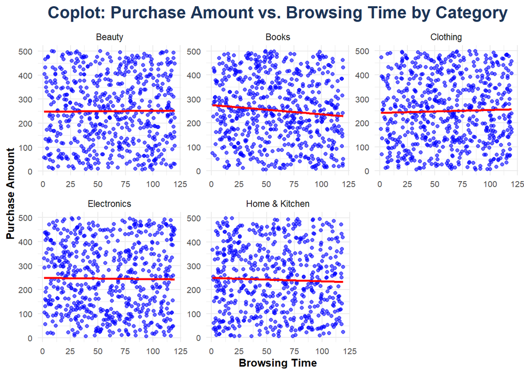

```r
ggplot(data, aes(x = Browsing_Time, y = Purchase_Amount)) +
  geom_point(alpha = 0.6, color = "blue") +
  geom_smooth(method = "lm", se = FALSE, color = "red") +
  facet_wrap(~ Category, scales = "free") +
  labs(title = "Coplot: Purchase Amount vs. Browsing Time by Category",
       x = "Browsing Time", y = "Purchase Amount") +
  theme_custom +
  theme(plot.title = element_text(hjust = 0.5, color = "#1D3557", size = 16, face = "bold"))
```

Overall, browsing time does not strongly influence purchase amount in most categories. Only Books show a slight negative trend (longer browsing times may be linked to slightly lower purchase amounts.), while Clothing shows a minor positive trend (longer browsing times may be linked to a minor increase in purchase amount). While other categories like Beauty, Electronics, and Home & Kitchen show little to no impact from browsing time.

#### 14. Use level plots or contour plots to visualize relationships between Browsing_Time, Number_of_Items, and Purchase_Amount.

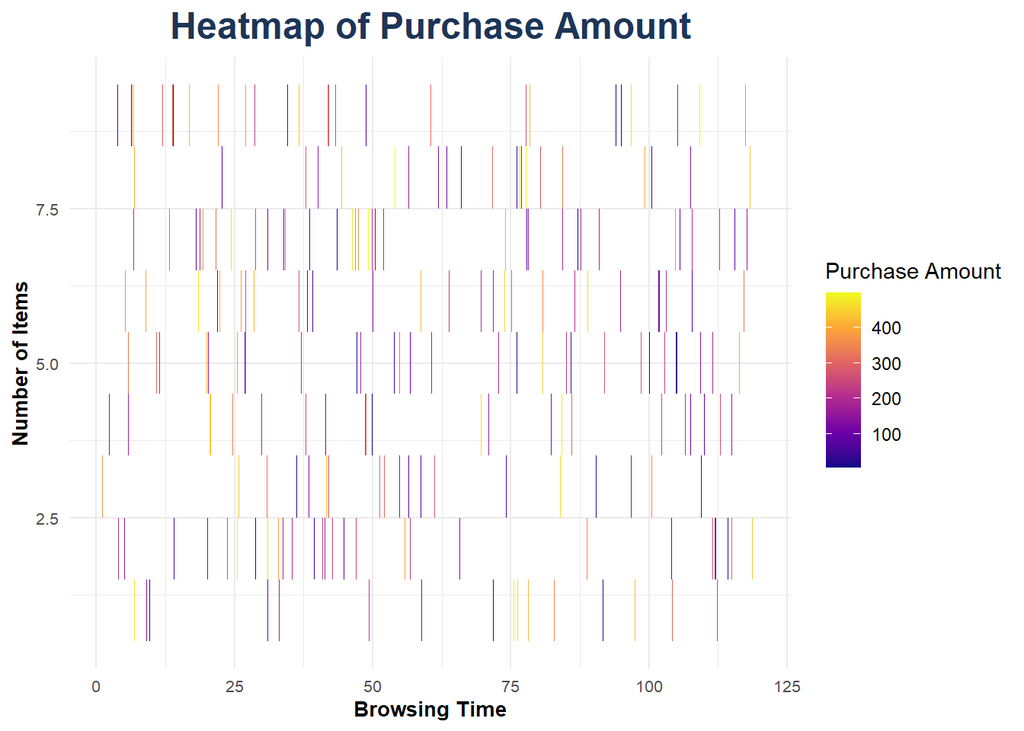

```r
ggplot(data, aes(x = Browsing_Time, y = Number_of_Items, fill = Purchase_Amount)) +
  geom_tile() +
  scale_fill_viridis_c(option = "plasma") +
  labs(title = "Heatmap of Purchase Amount", x = "Browsing Time", y = "Number of Items", fill = "Purchase Amount") +
  theme_custom +
  theme(plot.title = element_text(hjust = 0.5, color = "#1D3557", size = 18, face = "bold"))
```

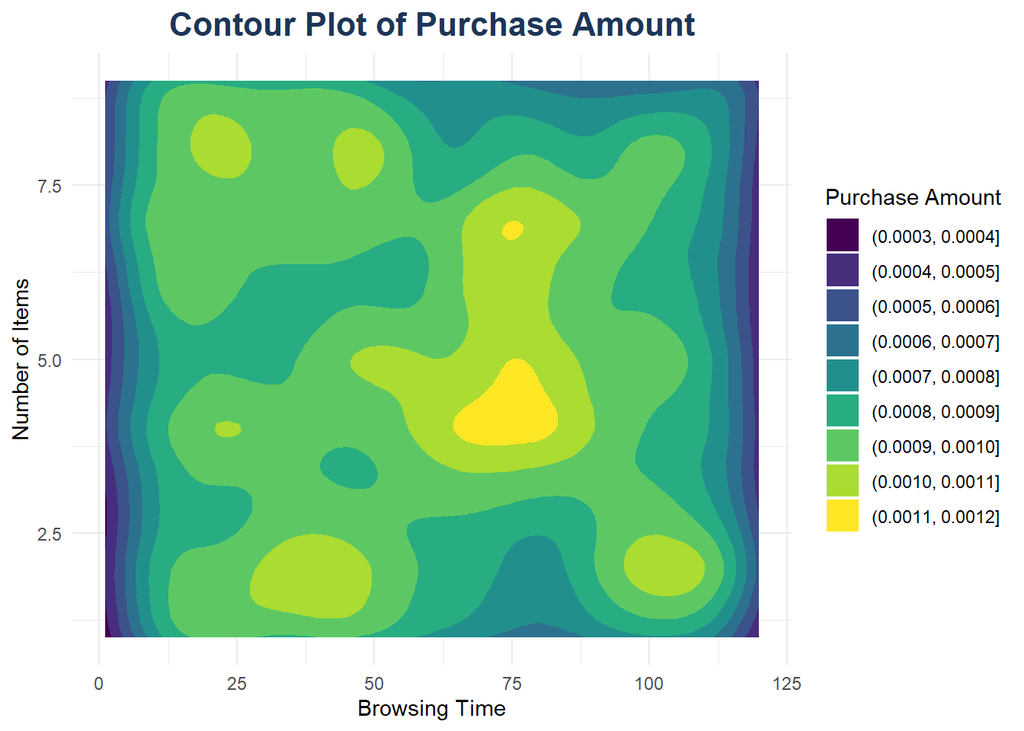

```r
ggplot(data, aes(x = Browsing_Time, y = Number_of_Items, z = Purchase_Amount)) +
  geom_density_2d_filled() +
  labs(title = "Contour Plot of Purchase Amount", x = "Browsing Time", y = "Number of Items", fill = "Purchase Amount") +
  theme_minimal() +
  theme(plot.title = element_text(hjust = 0.5, color = "#1D3557", size = 16, face = "bold"))
```

#### 15. Perform multiple regression with Purchase_Amount as the dependent variable and Browsing_Time, Number_of_Items, and Satisfaction_Score as predictors. Perform model selection and assess variable importance.

We will use the scaled coefficients (absolute values) to compare importance.

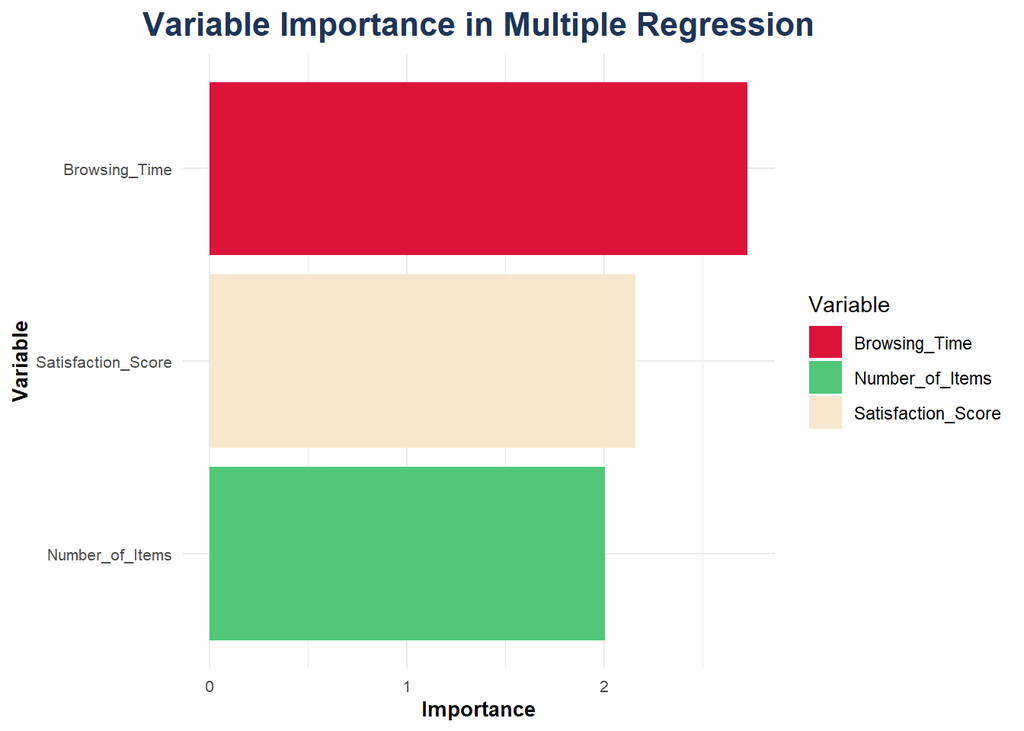

```r
library(caret)

data_scaled <- as.data.frame(scale(data[, c("Browsing_Time", "Number_of_Items", "Satisfaction_Score")]))
data_scaled$Purchase_Amount <- data$Purchase_Amount


multi_model_scaled <- lm(Purchase_Amount ~ ., data = data_scaled)

importance <- abs(coef(multi_model_scaled)[-1])

importance_df <- data.frame(Variable = names(importance), Importance = importance)

ggplot(importance_df,
       aes(x = reorder(Variable, Importance), y = Importance, fill = Variable)) +
  geom_bar(stat = "identity") +
  coord_flip() +
  scale_fill_manual(values = c("Browsing_Time" = "#DC143C",
                               "Number_of_Items" = "#50C878",
                               "Satisfaction_Score" = "#F7E7CE")) +
  labs(title = "Variable Importance in Multiple Regression",
       x = "Variable",
       y = "Importance") +
  theme_custom +
  theme(plot.title = element_text(hjust = 0.5, color = "#1D3557",
                                  size = 16, face = "bold"))
```

The bar plot helps visualize which predictor contributes most to Purchase_Amount. Since the bars are ordered from highest to lowest importance, the top variable (Browsing_Time) has the strongest influence on predicting Purchase_Amount.The second variable (Satisfaction_Score) has moderate importance. The last variable (Number_of_Items) has the least impact.

```r
multi_model <- lm(Purchase_Amount ~ Browsing_Time + Number_of_Items + Satisfaction_Score, data = data)

multi_summary <- summary(multi_model)

kable(tidy(multi_model), caption = "Multiple Regression Model Results", align = "c") %>%
  kable_styling(full_width = FALSE, bootstrap_options = c("striped", "hover"))
```

Multiple Regression Model Results

| term | estimate | std.error | statistic | p.value |
| --- | --- | --- | --- | --- |
| (Intercept) | 261.3499275 | 9.2492876 | 28.2562225 | 0.0000000 |
| Browsing_Time | -0.0795366 | 0.0750424 | -1.0598890 | 0.2892805 |
| Number_of_Items | -0.7832057 | 1.0049668 | -0.7793348 | 0.4358441 |
| Satisfaction_Score | -1.5387079 | 1.8344414 | -0.8387883 | 0.4016550 |

We can use stepwise regression (AIC-based) to find the best model.

```r
best_model <- stepAIC(multi_model, direction = "both")
```

```
## Start:  AIC=29691.89
## Purchase_Amount ~ Browsing_Time + Number_of_Items + Satisfaction_Score
##
##                      Df Sum of Sq      RSS   AIC
## - Number_of_Items     1     12056 59482958 29691
## - Satisfaction_Score  1     13966 59484867 29691
## - Browsing_Time       1     22299 59493201 29691
## <none>                            59470902 29692
##
## Step:  AIC=29690.5
## Purchase_Amount ~ Browsing_Time + Satisfaction_Score
##
##                      Df Sum of Sq      RSS   AIC
## - Satisfaction_Score  1     13479 59496437 29689
## - Browsing_Time       1     21541 59504498 29690
## <none>                            59482958 29691
## + Number_of_Items     1     12056 59470902 29692
##
## Step:  AIC=29689.18
## Purchase_Amount ~ Browsing_Time
##
##                      Df Sum of Sq      RSS   AIC
## - Browsing_Time       1     21676 59518113 29688
## <none>                            59496437 29689
## + Satisfaction_Score  1     13479 59482958 29691
## + Number_of_Items     1     11569 59484867 29691
##
## Step:  AIC=29688.27
## Purchase_Amount ~ 1
##
##                      Df Sum of Sq      RSS   AIC
## <none>                            59518113 29688
## + Browsing_Time       1     21676 59496437 29689
## + Satisfaction_Score  1     13614 59504498 29690
## + Number_of_Items     1     10822 59507290 29690
```

```r
summary(best_model)
```

```
##
## Call:
## lm(formula = Purchase_Amount ~ 1, data = data)
##
## Residuals:
##      Min       1Q   Median       3Q      Max
## -242.933 -119.268   -2.873  119.237  251.647
##
## Coefficients:
##             Estimate Std. Error t value Pr(>|t|)
## (Intercept)  247.963      2.572   96.41   <2e-16 ***
## ---
## Signif. codes:  0 '***' 0.001 '**' 0.01 '*' 0.05 '.' 0.1 ' ' 1
##
## Residual standard error: 140.9 on 2999 degrees of freedom
```

The best model is the baseline model with no predictors at all. Browsing_Time shows slight influence, but not enough to significantly improve model performance. This suggests that the provided predictors (Browsing_Time, Number_of_Items, Satisfaction_Score) are weak indicators of Purchase_Amount.